# HMWK2

Jiawen

2022-10-06

```r
library(tidyverse)
library(readr)
library(readxl)
library(lubridate)
library(psych)
```

```r
library(ggplot2)
library(data.table)
library(dplyr)
library(leaflet)
```

```r
chsindividual <- fread ("chs_individual.csv")
chsregional   <- fread ("chs_regional.csv")
```

```r
#merge two datasets using the location variable
chsmerged <-
  chsindividual %>%
  full_join(chsregional, by="townname")
```

#1.After merging the data, make sure you don’t have any duplicates by counting the number of rows. Make sure it matches. have question here

```r
dim(chsmerged)
```

```
## [1] 1200   47
```

```r
dim(chsindividual)
```

```
## [1] 1200   23
```

#In the case of missing values, impute data using the average within the variables “male” and “hispanic.”

```r
# mutate male and hispanic, then calculate the mean of new value? BMI FEV--lecture 5
which(is.na(chsindividual$male))
```

```
## integer(0)
```

```r
which(is.na(chsindividual$hispanic))
```

```
## integer(0)
```

```r
chsmerged [, bmiimp := fcoalesce(bmi, mean(bmi, na.rm = TRUE)),
by = .(male,hispanic)]
chsmerged [, fevimp := fcoalesce(fev, mean(fev, na.rm = TRUE)),
by = .(male,hispanic)]

  #dat[, temp_imp := fcoalesce(temp, mean(temp, na.rm = TRUE)),
    #by = .(STATE, year, month, day)]
```

it shows there is no missing value in case of Male and hispanic, we input the missing values of FEV, BMI by male and hispanic

#2.1 create a new categorical variable named “obesity_level” using the BMI measurement (underweight BMI<14; normal BMI 14-22; overweight BMI 22-24; obese BMI>24)

```r
    chsmerged[, obesity_level := fifelse(bmiimp<14, "underweight",
    fifelse(bmiimp<22, "normal",
    fifelse(bmiimp<=24, "overweight", "obese")))]
```

#2.2 To make sure the variable is rightly coded, create a summary table that contains the minimum BMI, maximum BMI, and the total number of observations per category.

```r
   chsmerged[, .(
  N          = .N,
  minbmi     = min(bmiimp),
  maxbmi     = max(bmiimp)
  ), by = obesity_level][order(obesity_level)]
```

```
##    obesity_level   N   minbmi   maxbmi
## 1:        normal 975 14.00380 21.96387
## 2:         obese 103 24.00647 41.26613
## 3:    overweight  87 22.02353 23.99650
## 4:   underweight  35 11.29640 13.98601
```

#3. Create another categorical variable named “smoke_gas_exposure” that summarizes “Second Hand Smoke” and “Gas Stove.” The variable should have four categories in total.

```r
    chsmerged [, smoke_gas_exposure := fifelse(
    smoke == 0 & gasstove == 0, "noexposure",
    fifelse(smoke == 1 & gasstove == 0, "smokeexposure",
    fifelse(smoke == 0 & gasstove == 1, "gasexposure","both")))]
```

#4. Create four summary tables showing the average (or proportion, if binary) and sd of “Forced expiratory volume in 1 second (ml)” and asthma indicator by town, sex, obesity level, and “smoke_gas_exposure.”

```r
##by town
chsmerged %>%
  group_by(townname) %>%
  summarise(
    avgfev = mean(fevimp, na.rm=T),
    sdfev = sd(fevimp, na.rm=T),
    propasthma = mean(asthma, na.rm=T)
  ) %>%
  knitr::kable()
```

| townname | avgfev | sdfev | propasthma |
| --- | --- | --- | --- |
| Alpine | 2087.101 | 291.1768 | 0.1134021 |
| Atascadero | 2075.897 | 324.0935 | 0.2551020 |
| Lake Elsinore | 2038.849 | 303.6956 | 0.1263158 |
| Lake Gregory | 2084.700 | 319.9593 | 0.1515152 |
| Lancaster | 2003.044 | 317.1298 | 0.1649485 |
| Lompoc | 2034.354 | 351.0454 | 0.1134021 |
| Long Beach | 1985.861 | 319.4625 | 0.1354167 |
| Mira Loma | 1985.202 | 324.9634 | 0.1578947 |
| Riverside | 1989.881 | 277.5065 | 0.1100000 |
| San Dimas | 2026.794 | 318.7845 | 0.1717172 |
| Santa Maria | 2025.750 | 312.1725 | 0.1340206 |
| Upland | 2024.266 | 343.1637 | 0.1212121 |

```r
##by sex
chsmerged %>%
  group_by(male) %>%
  summarise(
    avgfev = mean(fevimp, na.rm=T),
    sdfev = sd(fevimp, na.rm=T),
    propasthma = mean(asthma, na.rm=T)
  ) %>%
  knitr::kable()
```

| male | avgfev | sdfev | propasthma |
| --- | --- | --- | --- |
| 0 | 1958.911 | 311.9181 | 0.1208054 |
| 1 | 2103.787 | 307.5123 | 0.1727749 |

```r
##by obesity level
chsmerged %>%
  group_by(obesity_level) %>%
  summarise(
    avgfev = mean(fevimp, na.rm=T),
    sdfev = sd(fevimp, na.rm=T),
    propasthma = mean(asthma, na.rm=T)
  ) %>%
  knitr::kable()
```

| obesity_level | avgfev | sdfev | propasthma |
| --- | --- | --- | --- |
| normal | 1999.794 | 295.1964 | 0.1401475 |
| obese | 2266.154 | 325.4710 | 0.2100000 |
| overweight | 2224.322 | 317.4261 | 0.1647059 |
| underweight | 1698.327 | 303.3983 | 0.0857143 |

```r
##by smoke_gas_exposure
chsmerged %>%
  group_by(smoke_gas_exposure) %>%
  summarise(
    avgfev = mean(fevimp, na.rm=T),
    sdfev = sd(fevimp, na.rm=T),
    propasthma = mean(asthma, na.rm=T)
  ) %>%
  knitr::kable()
```

| smoke_gas_exposure | avgfev | sdfev | propasthma |
| --- | --- | --- | --- |
| both | 2019.867 | 298.9728 | 0.1301370 |
| gasexposure | 2025.989 | 317.6305 | 0.1477428 |
| noexposure | 2055.356 | 330.4169 | 0.1476190 |
| smokeexposure | 2055.714 | 295.6475 | 0.1714286 |
| NA | 2001.878 | 340.2592 | 0.1489362 |

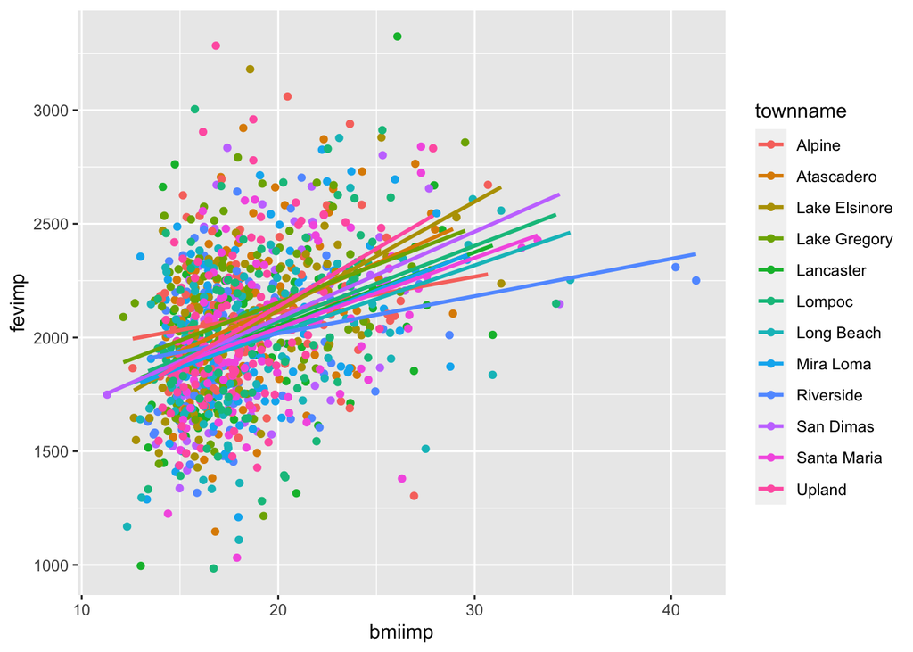

```r
  chsmerged %>%
  ggplot(aes(x = bmiimp, y = fevimp, color=townname, line=townname)) +
  geom_point() +
  geom_smooth(se = F, method = "lm")
```

```r
  lm(fevimp ~ bmiimp, data = chsmerged)
```

```
##
## Call:
## lm(formula = fevimp ~ bmiimp, data = chsmerged)
##
## Coefficients:
## (Intercept)       bmiimp
##     1452.46        31.22
```

bmi and fev are positively related

#EDA 2.Stacked histograms of FEV by BMI category and FEV by smoke/gas exposure. Use different color schemes than the ggplot default.

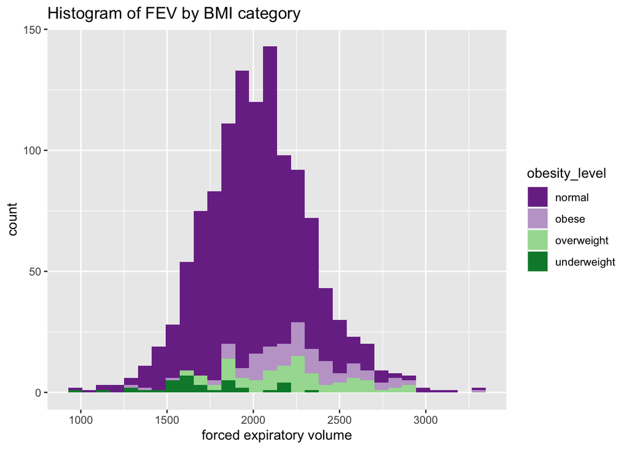

```r
chsmerged %>%
  ggplot(aes(x=fevimp,fill=obesity_level))+
  geom_histogram(aes(x=fevimp,fill=obesity_level))+
  scale_fill_brewer(palette='PRGn')+
  labs(title = "Histogram of FEV by BMI category", x="forced expiratory volume")
```

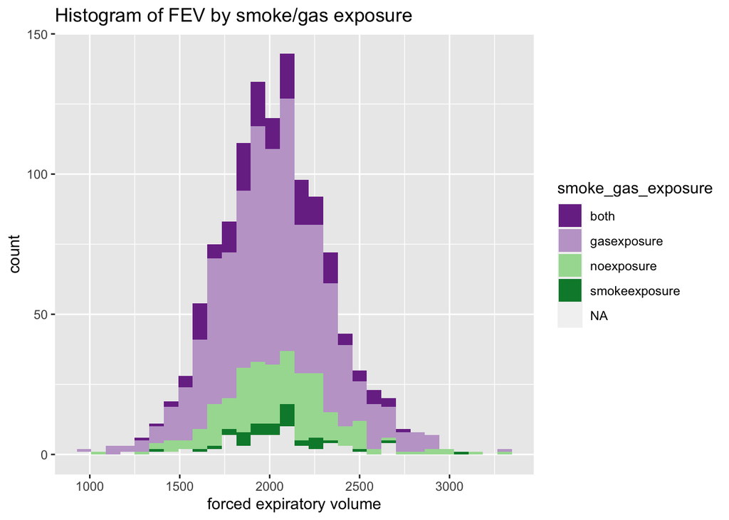

```r
chsmerged %>%
  ggplot(aes(x=fevimp,fill=smoke_gas_exposure))+
  geom_histogram(aes(x=fevimp,fill=smoke_gas_exposure))+
  scale_fill_brewer(palette='PRGn')+
  labs(title = "Histogram of FEV by smoke/gas exposure", x="forced expiratory volume")
```

The amount of People whose BMI is “normal” is greater than other categories, and from this graph we can say its relationship with FEV it is basically near to normally distribution

The amount of people who expose to gas is significantly higher than other gas or smoke exposure categories, and from this graph we can say its relationship with FEV it is basically near to normally distribution

#EDA 3. Barchart of BMI by smoke/gas exposure.

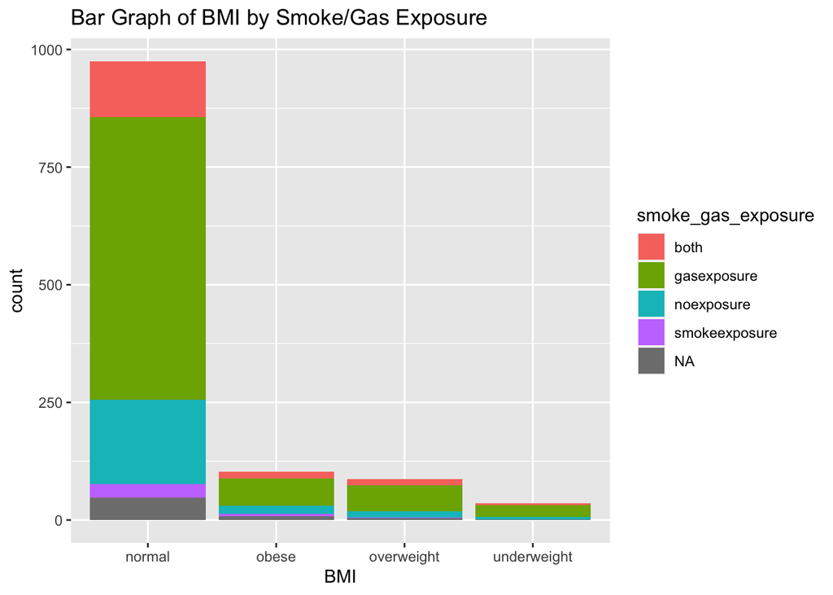

```r
chsmerged %>%
  ggplot(mapping = aes(x = obesity_level, fill = smoke_gas_exposure))+
  geom_bar() +
    labs(title = "Bar Graph of BMI by Smoke/Gas Exposure", x = "BMI")
```

No matter what type of BMI that people belong to, most of them are proposed to gas. #EDA 4. Statistical summary graphs of FEV by BMI and FEV by smoke/gas exposure category.

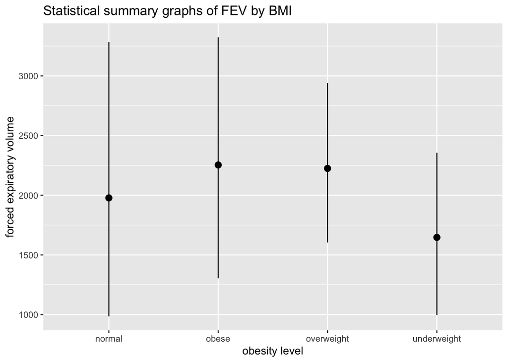

```r
chsmerged %>%
  ggplot() +
    stat_summary(mapping = aes(x = obesity_level, y = fevimp),
    fun.min = min,
    fun.max = max,
    fun = median)+
    labs(title = "Statistical summary graphs of FEV by BMI", x = "obesity level", y = "forced expiratory volume")
```

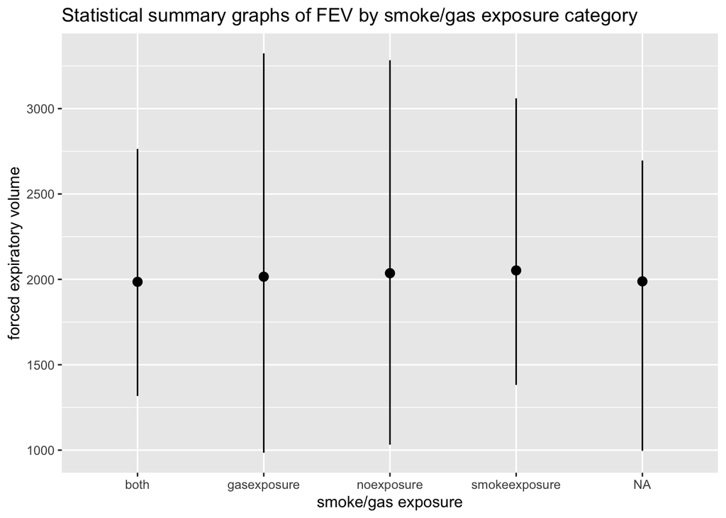

```r
chsmerged %>%
  ggplot() +
    stat_summary(mapping = aes(x = smoke_gas_exposure, y = fevimp),
    fun.min = min,
    fun.max = max,
    fun = median)+
    labs(title = "Statistical summary graphs of FEV by smoke/gas exposure category", x = "smoke/gas exposure", y = "forced expiratory volume")
```

the mean of FEV in different smoke/gas exposure groups are approximate

```r
# Generating a color palette
#pm25.pal <- colorNumeric(c('darkgreen','goldenrod','brown'), domain=chsmerged$pm25_mass)
#chsmap <- leaflet(chsmerged) %>%
  #addProviderTiles('CartoDB.Positron') %>%
  #addCircles(lat=~lat, lng=~lon,
     #label = ~`pm25_mass`, color = ~ pm25.pal(pm25_mass),
     #opacity = 1, fillOpacity = 1, radius = 60
    #) %>%
  # And a pretty legend
  #addLegend('bottomleft', pal=pm25.pal, values=chsmerged$pm25_mass,
          #title='PM2.5 mass', opacity=1)
```